# Sesión 4 - Metodología Box Jenkins completa

Universidad Nacional de Colombia - Facultad de Ciencias Económicas

Monitorías Econometría II

2023-02

En este script de R-Markdown, presentaremos la metodología Box-Jenkins completa para la identificación, estimación, validación y pronóstico para series de tiempo.

En R, podemos trabajar con 4 objetos para el manejo de series de tiempo: ts, zoo, xts y tstibble.

**ts:**

Es el tipo de objeto estándar para manejar series de tiempo en R.

- Su principal ventaja es que son prácticamente compatibles con cualquier función diseñada para tabajar series de tiempo en R, lo que los hace objetos muy universales y comúnmente usados.
- Tienen la desventaja de que solo funcionan con periodos o intervalos de tiempo fijos (mensual, trimestral, anual).

Adicionalmente, prácticamente cualquier otro tipo de objeto de serie de tiempo se puede transformar fácilmente a un objetos ts usando el comando as.ts(). Además, fueron los primeros objetos en diseñarse para trabajar series de tiempo en R por lo que no tienen todas las funcionalidades que sí tienen otros objetos de series de tiempo más modernos como xts o tsibble.

**zoo:**

Son objetos para manejar series de tiempo que fueron diseñados para tener funcionalidades adicionales frente a los objetos ts. Hoy en día se usan más los objetos que resultaron de su evolución los cuales se conocen como xts.

**xts:**

Son objetos para manejar series de tiempo que están diseñados para ser más flexibles y poderosos en términos de modelamiento; diseñados para facilitar el uso de las series temporales.  
Además, son muy útiles para el modelamiento de series financieros con intervalos de tiempo que nos son fijos. Están basados en zoo, pero son una versión avanzada de éstos.

**tsibble:**

Son objetos diseñados para ser compatibles con los paquetes “tidyverse” de R, lo que implica que se pueden emplear directamente en ellos las funciones de ggplot2 (graficación) y de dplyr (manipulación de base de datos) del tidyverse. Básicamente, son parecidos a un dataframe pero que permite manejar series de tiempo, lo que implica que trabajar varias series de tiempo de manera simultanea sea muy sencillo. Su nombre es una combinación de: ts + tibble. ts para denotar que maneja series de tiempo y tibble para denotar que son una forma especila de tibble (recuerden que tibble es un tipo de dataframe destinado a trabajar optimamente con los paquetes del tidyverse). Son necesarios para emplear las funciones del paquete “fable”, por lo que tienen que transformar sus series a este tipo de objeto antes de poder utilizar las funciones de “fable” Para transformar un objeto de serie de tiempo a tsibble se usa el comando as_tsibble(). En la actualidad solo es posible convertir directamente de objeto ts a tsibble, no es posible hacer la conversión directa entre xts a tsibble.

Para aprender más sobre tsibble se recomienda revisar: https://tsibble.tidyverts.org/

**Sobre la estacionalidad de las series:** Recordemos que una serie temporal sin destacionalizar o estacionalizada, es aquella en la que no se han eliminado las fluctuaciones regulares y predecibles que ocurren en intervalos de tiempo específicos, lo que incluye efectos estacionales como estacionalidad mensual o trimestral (Un ejemplo es el aumento de consumo en junio y diciembre de las series de consumo).

Tener en cuenta que para cualquier modelamiento con series de tiempo lo primero que hay que investigar es si la serie está desestacionalizada o no.

Si la serie presenta estacionalidad, hay dos alternativas:

- 1. Desestacionalizar la serie de tiempo empleando alguna metodología como X-13 que emplea la FED y se encuetra disponible en la función “seas()” del paqueta seasonal.
- 2. Modelar la estacionalidad en la serie, por ejemplo mediante un modelo SARIMA, sin embargo, esta estimación se sale de los contenidos del curso.

Para los talleres se les aconseja buscar series que ya se encuentren desetacionalizadas. Una buena fuente de datos que incluye muchas series desestacionaliadas (en inglés seasonal-adjusted) se encuentran en la página de la reserva federal de St. Louis: https://www.stlouisfed.org/).

## Instalación de paquetes

Descargamos e importamos los paquetes que vayamos a usar con el paquete “pacman”

```r
library(pacman)
```

Pacman contiene una función denominada “p_load” que permite al usuario descargar un paquete e importarlo si no lo tiene, y si el usuario tiene descargado el paquete, Pacman lo importa automáticamente. Veamoslo.

```r
pacman::p_load(

  forecast,   # Para hacer pronósticos con modelos arima
  lmtest,     # Significancia individual de los coeficientes ARIMA
  urca,       # Prueba de raíz unitaria
  tseries,    # Para estimar modelos de series de tiempo y hacer pruebas de supuestos
  stargazer,  # Para presentar resultados más estéticos
  psych,      # Para hacer estadísticas descriptiva
  seasonal,   # Para desestacionalizar series
  aTSA,       # Para hacer la prueba de efectos ARCH
  astsa,      # Para estimar, validar y hacer pronósticos para modelos ARIMA/SARIMA
  xts,        # Para utilizar objetos xts
  tidyverse,  # Conjunto de paquetes (incluye dplyr y ggplot2)
  readxl,     # Para leer archivos excel
  car,        # Para usar la función qqPlot

  # Paquetes del tidyverts

  fable,      # Forma moderna de hacer pronóstiocs en R (se recomienda su uso)
  tsibble,    # Para poder emplear objetos de series de tiempo tsibble
  feasts      # Provee una colección de herramientas para el análisis de datos de series de tiempo
)
```

En este script modelaremos las siguientes series:

- Índice de Producción Industrial (IPI)

# 1. Primer paso: Identificación

Vamos a trabajar con el industrial production index de los EE.UU. el cual es un indicador económico que mide la producción real de los Estados Unidos en términos de manufactura, minería, electicidad y gas.

Fuente: https://fred.stlouisfed.org/series/INDPRO#0 (Tomados de la FRED de la Reserva Federa de St. Louis)

Se carga la serie y se visualizan los datos.

```r
base_fred = read_excel(file.choose())

# Visualización de la base de datos
glimpse(base_fred)
```

```
## Rows: 211
## Columns: 2
## $ observation_date <dttm> 1960-01-01, 1960-04-01, 1960-07-01, 1960-10-01, 1961…
## $ INDPRO           <dbl> 24.67430, 24.13890, 23.74197, 23.16967, 22.81890, 23.…
```

```r
View(base_fred)
```

R identifica estos datos como si fuesen corte transversal, para hacer que R entiend que son series de tiempo, usamos “ts()” o “xts()”.

Para ts, especifícamos el inicio de la serie y su frecuencia. Si colocamos frecuencia = 4, indica una periodicidad trismetral, 12 indica periocidad mensual, 1 indica periocidad anual.

```r
indprod = ts(base_fred$INDPRO, start = 1960, frequency = 4)


glimpse(indprod)
```

```
##  Time-Series [1:211] from 1960 to 2012: 24.7 24.1 23.7 23.2 22.8 ...
```

```r
view(indprod)
```

Con xts importamos de la siguiente forma.

```r
indprod_xts = xts(base_fred$INDPRO,
                  order.by = base_fred$observation_date)
```

Podemos notar que las clases corresponden a los objetos de series de tiempo.

```r
class(indprod)
```

```
## [1] "ts"
```

```r
class(indprod_xts)
```

```
## [1] "xts" "zoo"
```

## 1.1. Análisis Gráfico

**Gráficas de la serie**

Para el objeto ts, usamos la función “plot.ts()” para graficar.

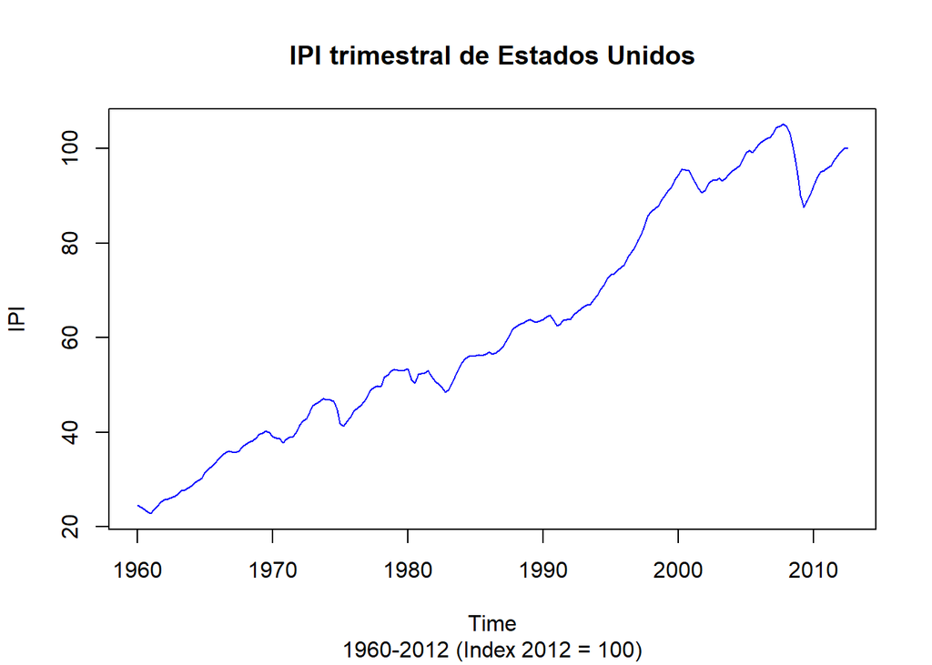

```r
plot.ts(indprod, xlab="Time",ylab="IPI",
        main="IPI trimestral de Estados Unidos",
        sub = "1960-2012 (Index 2012 = 100)"
        ,lty=1, lwd=1, col="blue")
```

Con ggplot2 usamos “autoplot()”

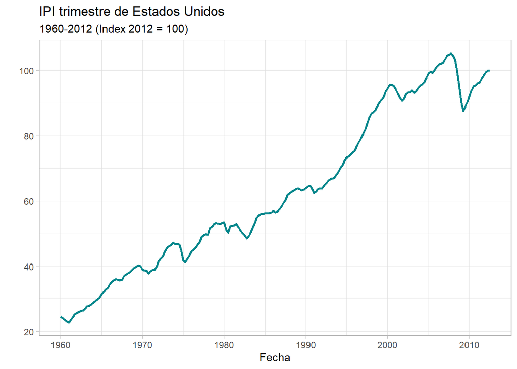

```r
autoplot(indprod, col="turquoise4",
         xlab = "Fecha", ylab="", lwd=1)+
         theme_light()+
         ggtitle("IPI trimestre de Estados Unidos",
                 subtitle = "1960-2012 (Index 2012 = 100)")
```

Gráfica mucho más linda e informativa usando xts

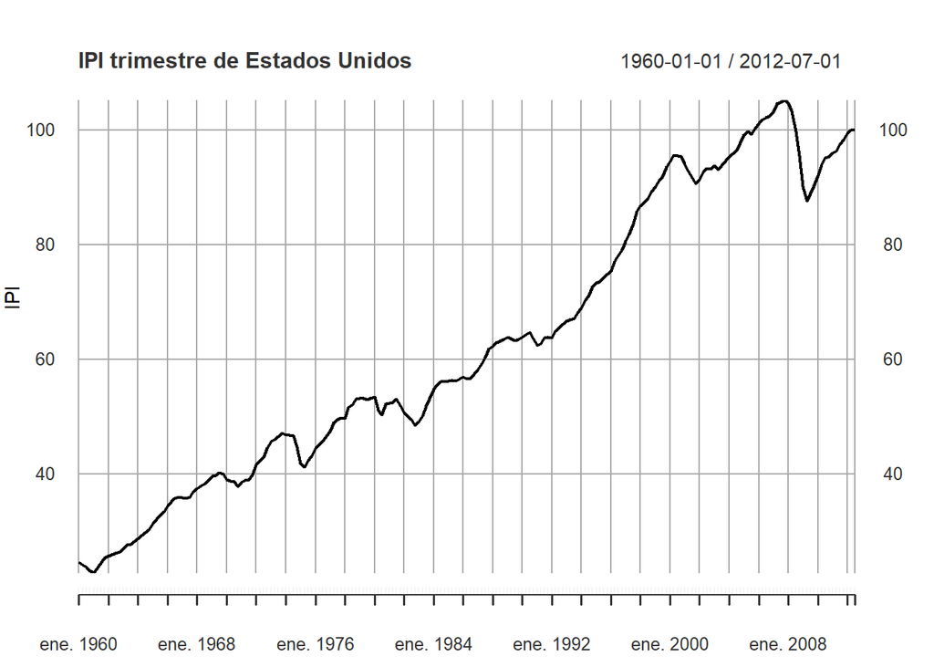

```r
plot(indprod_xts, main = "IPI trimestre de Estados Unidos",
     sub = "1960-2010 (Index 2012 = 100)",
     ylab  = "IPI")
```

**Gráficas de las FAC y FACP**

Versión base de R.

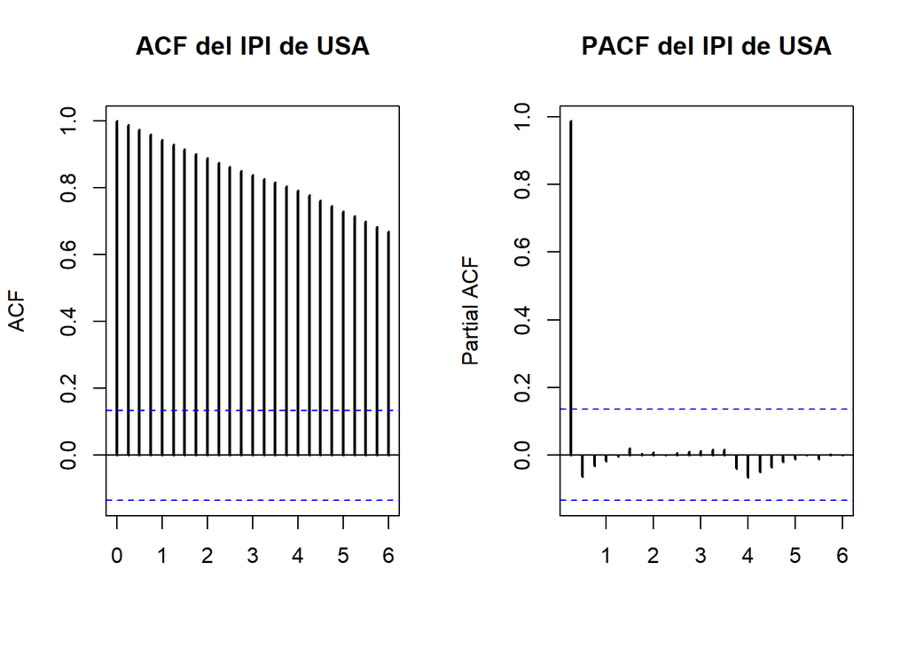

```r
lags=24

par(mfrow=c(1,2))

acf(indprod,lag.max=lags,plot=T,lwd=2,xlab='',main='ACF del IPI de USA')
pacf(indprod,lag.max=lags,plot=T,lwd=2,xlab='',main='PACF del IPI de USA')
```

Versión ggplot2.

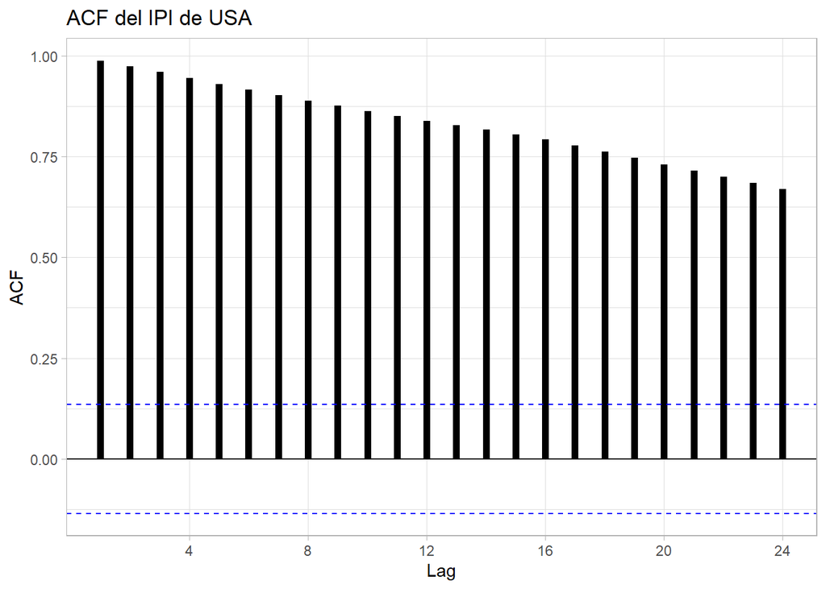

```r
ggAcf(indprod,lag.max=lags,plot=T,lwd=2) + ggtitle("ACF del IPI de USA") + theme_light()
```

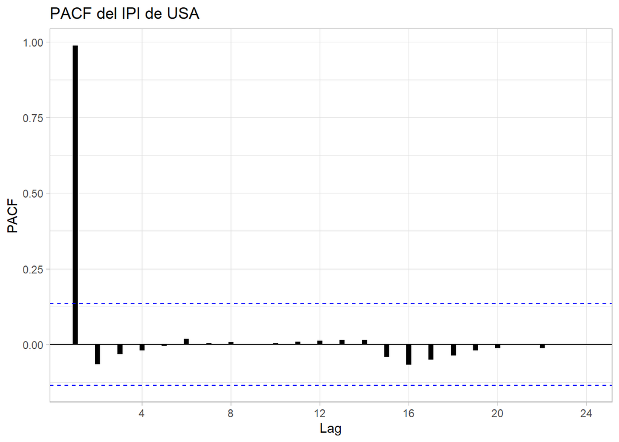

```r
ggPacf(indprod,lag.max=lags,plot=T,lwd=2) + ggtitle("PACF del IPI de USA") + theme_light()
```

Como podemos ver, la FAC tiene un decaimento lento a cero,lo que nos da indicios de que el proceso no es estacionario.

## 1.2. Prueba Dickey Fuller aumentada

La ADF es una prueba estándar muy utilizada para saber si una serie de tiempo tiene al menos una raíz unitaria o no.

La presencia de una raíz unaitaria hace que la serie de tiempo estudiada no sea estacionaria. A la hora de utilizar la metodología Box Jenkins para series ARIMA es importante trabajar con una serie estacionaria o con una una serie no estacionaria debidamente diferenciada para que la serie diferenciada (pueden ser varias diferencias) sea estacionaria y de ahí la importancia de la pruba ADF para la identificación de series estacionarias.

Dado que aún no se han visto pruebas de raíz unitaria se colocará el resultado de la prueba por completitud Y en scripts posteriores se les indicará como es la mecánica de la prueba y como interpretar sus resultados.

Prueba con trend

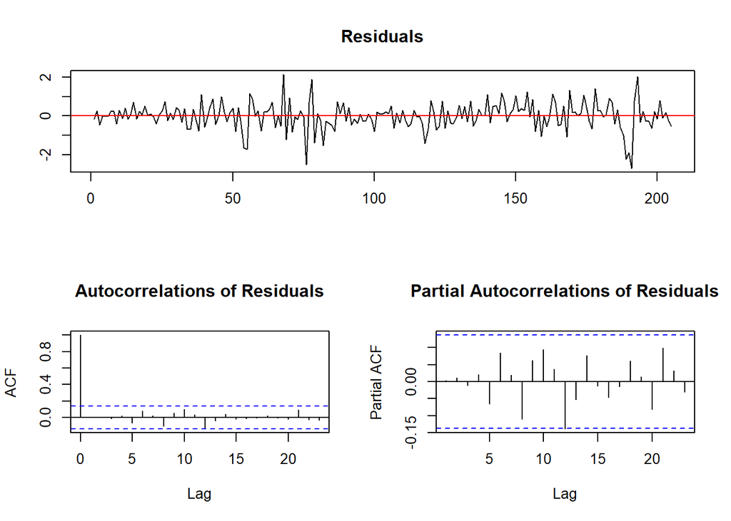

```r
adf.trend_indprod= ur.df(indprod, type="trend", lags = 5)
plot(adf.trend_indprod)
```

```r
summary(adf.trend_indprod)
```

```
##
## ###############################################
## # Augmented Dickey-Fuller Test Unit Root Test #
## ###############################################
##
## Test regression trend
##
##
## Call:
## lm(formula = z.diff ~ z.lag.1 + 1 + tt + z.diff.lag)
##
## Residuals:
##      Min       1Q   Median       3Q      Max
## -2.70702 -0.37098  0.02974  0.33554  2.13919
##
## Coefficients:
##              Estimate Std. Error t value Pr(>|t|)
## (Intercept)  0.676376   0.242716   2.787  0.00585 **
## z.lag.1     -0.024269   0.010915  -2.223  0.02732 *
## tt           0.009367   0.004383   2.137  0.03383 *
## z.diff.lag1  0.783147   0.070090  11.173  < 2e-16 ***
## z.diff.lag2 -0.202340   0.088794  -2.279  0.02375 *
## z.diff.lag3  0.152490   0.089495   1.704  0.08998 .
## z.diff.lag4 -0.121466   0.088664  -1.370  0.17226
## z.diff.lag5 -0.023203   0.071115  -0.326  0.74456
## ---
## Signif. codes:  0 '***' 0.001 '**' 0.01 '*' 0.05 '.' 0.1 ' ' 1
##
## Residual standard error: 0.7098 on 197 degrees of freedom
## Multiple R-squared:  0.4963, Adjusted R-squared:  0.4784
## F-statistic: 27.73 on 7 and 197 DF,  p-value: < 2.2e-16
##
##
## Value of test-statistic is: -2.2235 4.7223 2.5001
##
## Critical values for test statistics:
##       1pct  5pct 10pct
## tau3 -3.99 -3.43 -3.13
## phi2  6.22  4.75  4.07
## phi3  8.43  6.49  5.47
```

Prueba con drift

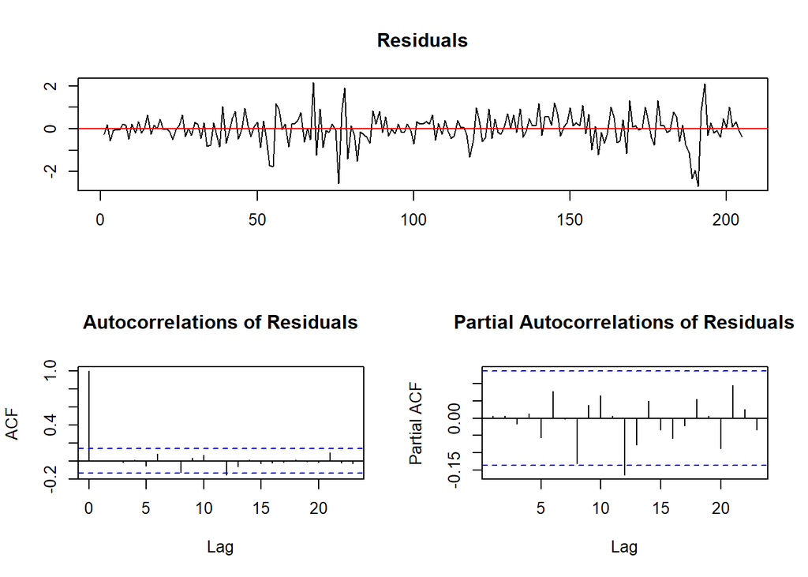

```r
adf.drift_indprod= ur.df(indprod, type="drift", lags = 5)
plot(adf.drift_indprod)
```

```r
summary(adf.drift_indprod)
```

```
##
## ###############################################
## # Augmented Dickey-Fuller Test Unit Root Test #
## ###############################################
##
## Test regression drift
##
##
## Call:
## lm(formula = z.diff ~ z.lag.1 + 1 + z.diff.lag)
##
## Residuals:
##      Min       1Q   Median       3Q      Max
## -2.69340 -0.32642  0.02946  0.34499  2.15511
##
## Coefficients:
##              Estimate Std. Error t value Pr(>|t|)
## (Intercept)  0.257451   0.144394   1.783   0.0761 .
## z.lag.1     -0.001375   0.002106  -0.653   0.5148
## z.diff.lag1  0.784009   0.070718  11.086   <2e-16 ***
## z.diff.lag2 -0.215363   0.089379  -2.410   0.0169 *
## z.diff.lag3  0.140546   0.090121   1.560   0.1205
## z.diff.lag4 -0.130922   0.089347  -1.465   0.1444
## z.diff.lag5 -0.050276   0.070605  -0.712   0.4773
## ---
## Signif. codes:  0 '***' 0.001 '**' 0.01 '*' 0.05 '.' 0.1 ' ' 1
##
## Residual standard error: 0.7162 on 198 degrees of freedom
## Multiple R-squared:  0.4847, Adjusted R-squared:  0.469
## F-statistic: 31.04 on 6 and 198 DF,  p-value: < 2.2e-16
##
##
## Value of test-statistic is: -0.6526 4.7152
##
## Critical values for test statistics:
##       1pct  5pct 10pct
## tau2 -3.46 -2.88 -2.57
## phi1  6.52  4.63  3.81
```

Los resultados de la prueba indican que la serie debería tener término de deriva (drift) Y que la serie no es estacionaria, por lo que hay que diferenciarla para eliminar raíces unitarias.

## 1.3. Transformación para volver estacionaria una serie

Recordemos que para volver una serie estacionaria, podemos aplicar el operador de diferencia. Además, podemos estabilizar la varianza usando el logaritmo natural.

```r
d.indprod= diff(indprod) # Serie diferenciada
```

```r
l.indprod=log(indprod) # Serie que se le aplica solo el logaritmo
```

```r
dl.indprod= diff(log(indprod))*100   # Diferencia de logaritmos de la serie
                                     # (tasa de crecimiento)
```

IMPORTANTE: Primero se aplica log y luego diff si van a usar ambos.

Vamos a graficar ahora su nivel, su variación, su tasa de crecimiento y su valor en logaritmos.

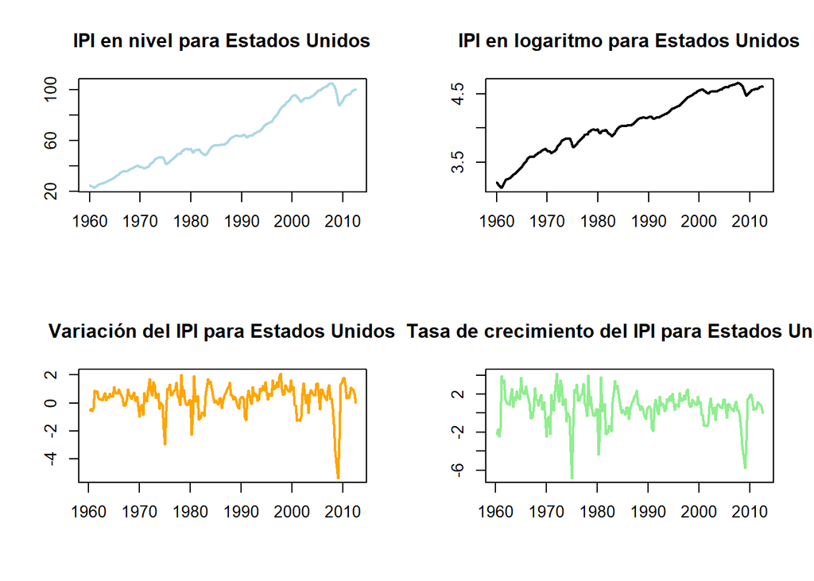

```r
par(mfrow=c(2,2))

plot.ts(indprod, xlab="",ylab="",
        main="IPI en nivel para Estados Unidos",lty=1, lwd=2, col="lightblue")
plot.ts(l.indprod, xlab="",ylab="",
        main="IPI en logaritmo para Estados Unidos",lty=1, lwd=2, col="black")
plot.ts(d.indprod, xlab="",ylab="",
        main="Variación del IPI para Estados Unidos",lty=1, lwd=2, col="orange")
plot.ts(dl.indprod, xlab="",ylab="",
        main="Tasa de crecimiento del IPI para Estados Unidos",lty=1,
        lwd=2, col="lightgreen")
```

Elegimos la tasa de crecimiento del IPI, es decir “dl.indrod”.

## 1.4. Funciones para idenficar modelo ARIMA por criterios de información

### 1.4.1. Método Manual

Ya tenemos nuestra serie objetivo a estimar, la variación del IPI de Estados Unidos, ahora escogeremos que orden ARIMA(p,d,q) para generar la estimación del modelo y obtener los respectivos coeficientes. Supondremos un orden máximo para los ordenes “p” y “q” en primer lugar.

```r
AR.m <- 6
MA.m <- 6
```

Para identificar el ARIMA usando los criterios de información usaremos un método manual. Para ello traemos las siguientes funciones que nos retornaran un Data.Frame con los mejores ARIMA organizados por los menores criterios de información. Se debe seleccionar el método máxima verosimilitud para estimar (ML), de lo contrario arrojará error.

```r
#~~~ FUNCIÓN PARA SELECCIONAR ARIMA CON EL MENOR CRITERIO DE INFORMACIÓN ~~~#

arma_seleccion_df = function(ts_object, AR.m, MA.m, d, bool_trend, metodo){

  index = 1
  df = data.frame(p = double(), d = double(), q = double(), AIC = double(), BIC = double())
  for (p in 0:AR.m) {
    for (q in 0:MA.m)  {
      fitp <- arima(ts_object, order = c(p, d, q), include.mean = bool_trend,
                    method = metodo)
      df[index,] = c(p, d, q, AIC(fitp), BIC(fitp))
      index = index + 1
    }
  }
  return(df)
}

#~~~ FUNCIÓN PARA SELECCIONAR ARIMA POR MENOR AIC ~~~#

arma_min_AIC = function(df){
  df2 = df %>%
    filter(AIC == min(AIC))
  return(df2)
}

#~~~ FUNCIÓN PARA SELECCIONAR ARIMA POR MENOR BIC ~~~#


arma_min_BIC = function(df){
  df2 = df %>%
    filter(BIC == min(BIC))
  return(df2)
}
```

Noten que el argumento “d” de la función ARIMA indica el número de veces que debemos diferenciar la serie para que sea estacionaria. No hace falta especificar d=1 si ya estamos trabajando con las serie diferenciada. En nuestro caso tenemos la tasa de crecimiento del IPI (dl.indrod) por lo que no hará falta usar el argumento de diferencia (d).

Usaremos la función que hemos creado denominada arma_seleccion_df para escoger el ARIMA a usar, con los máximos rezagos que hemos fijado (p = 6, q = 6) y con 0 diferencias para nuestra serie.

```r
mod_d0_indprod = arma_seleccion_df(dl.indprod, AR.m, MA.m, d = 0, TRUE, "ML")
# Visualización de los criterios de información de los ARIMA.

View(mod_d0_indprod)
```

Ahora, con la función “arma_min_AIC()” y “arma_min_BIC()” seleccionamos cada ARIMA según su criterio menor.

Generalmente los modelos del criterio de información BIC son más parsiomoniosos que el AIC. Si bien, esto es conveniente en el sentido que hay que estimar pocos parámetros, puede que si el modelo resulta ser demasiado parsimonioso los errores no se comportaran como ruido blanco. En este caso, es necesario emplear el modelo sugerido por el AIC u otro modelo menos parsimonioso. Es muy importante, que en la validación de supuestos los residuales del modelo ARIMA se comporten como ruido blanco, en particular, es muy importante que se satisfaga el supuesto de no correlación serial en los residuales. Si este supuesto no se satisface, entonces hay estrucutras de correlación en la serie que no se están modelando apropiadamente y por ende hay que nuevamente seleccionar un nuevo modelo ARIMA.

```r
min_aic_dlindprod = arma_min_AIC(mod_d0_indprod)
min_aic_dlindprod
```

```
##   p d q      AIC     BIC
## 1 2 0 4 688.1861 714.963
```

```r
min_bic_dlindprod = arma_min_BIC(mod_d0_indprod)
min_bic_dlindprod
```

```
##   p d q      AIC     BIC
## 1 2 0 4 688.1861 714.963
```

Ambos criterios de información sugieren un ARIMA(2,0,4). Suele ser bueno cuando los criterios se coordinan, sin embargo, este modelo no es del todo parsimonioso.

### 1.4.2. Función ARIMA de Fable

En primer lugar, es pertinente conocer algunas características del paquete Fable.

Fable fue diseñado para reemplazar al paquete forecast (ambos paquetes están diseñados para hacer pronósticos de series de tiempo). Además, ambos paquetes fueron diseñados por Rob J Hyndman, no obstante, el paquete fable es más avanzado y más moderno que forecast (es en muchos aspectos como su evolución). Fable ofrece una colección de modelos de pronóstico para series de tiempo, tanto univariadas como multivariadas (pronósticos en modelos ARIMA, VAR y mucho más). Adicionalmente, fable hace parte de una colección de paquetes que se conoce como “tidyverts” que está diseñado para trabajar de manera práctica series de tiempo usando el entorno de trabajo del “tidyverse”

Algunos links de interés relacionados con el paquete fable son:

- Link de referencia con las funciones disponibles en fable: https://fable.tidyverts.org/reference/index.html
- Como emplear el comando ARIMA de fable: https://otexts.com/fpp3/arima-r.html
- Para instalación y generalidades del paquete: https://fable.tidyverts.org/index.html
- Documentación sobre el conjunto de paquetes del tidyverts: https://tidyverts.org/
- Libro oficial del autor del paquete para el manejo de series de tiempo en R: https://otexts.com/fpp3/index.html
- página de CRAN para el paquete fable: https://cran.r-project.org/web/packages/fable/index.html

Retomando, para usar las funciones del paquete Fable, debemos de usar objetos de clase “tsibble”.

```r
dl.indprod_tsibble = as_tsibble(dl.indprod)
l.indprod_tsibbble = as_tsibble(l.indprod)
```

Veamos sus generalidades.

```r
class(dl.indprod_tsibble)
```

```
## [1] "tbl_ts"     "tbl_df"     "tbl"        "data.frame"
```

```r
glimpse(dl.indprod_tsibble)
```

```
## Rows: 210
## Columns: 2
## $ index <qtr> 1960 Q2, 1960 Q3, 1960 Q4, 1961 Q1, 1961 Q2, 1961 Q3, 1961 Q4, 1…
## $ value <dbl> -2.1937569, -1.6580419, -2.4400276, -1.5254812, 3.8875573, 3.140…
```

```r
view(dl.indprod_tsibble)
```

Como se puede observar, tsibble es un tipo de dataframe diseñado o adaptado para trabajar con series de tiempo Una de las ventajas de emplear tsibble radica en que, al ser un dataframe, permite trabajar con varias series de tiempo al mismo tiempo. Otra razón por la que es conveniente emplear tsibble es que al ser un tibble (tibble son los dataframes que se emplean en los paquetes del tidyverts) permite emplear con facilidad toda las metodologías y funcionalidades de los paquetes del tidyverts como lo son: ggplot2, dplyr, tidyr, lubridate y demás.

Fable nos permitirá ver un gráfico conjunto de la serie de tiempo, su FAC y FACP con gg_tsdisplay.

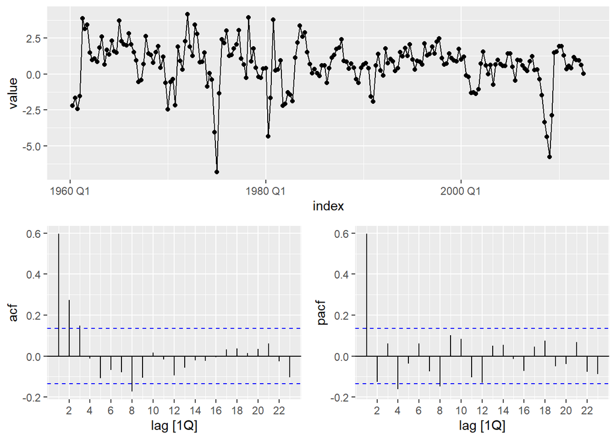

```r
gg_tsdisplay(dl.indprod_tsibble, value, plot_type = "partial")
```

Para identiciar el modelo ARIMA usando criterios de información se empela la función ARIMA del paquete fable. La identificación se puede hacer usando AIC o BIC como criterios de información. Existen dos formas en las que ARIMA puede identificar el mejor modelo usando criterios de inforamción:

1. stepwise (método default): metodología simplificado para encontrar los parámetros p,d,q empleando el algoritmo Hyndman-Khandakar.
2. search: realiza una busqueda más exhuastiva del mejor modelo ARIMA dada la series de tiempo.

Para este caso usaremos el método search. Cabe destacar que esta función sugiere automaticamente modelos SARIMA, es decir, modelando la estacionaliedad. Si obtenemos un modelo SARIMA, será ignorado debido a que la base empleada del IPI de Estados Unidos ya esta estacionalmente ajustadam, estas son algunas de las limitaciones de usar funciones prediseñadas.

Con ayuda de la función model() y pivot_longer() (Vista anteriormente en la sesión 1), obtendremos los ARIMA que sugiere Fable con la sentencia “search”.

**Criterio AIC:**

```r
dl.indprod_fit_aic = dl.indprod_tsibble %>%
  model(stepwise = ARIMA(value, ic = "aic"),
        search = ARIMA(value, ic = "aic", stepwise=FALSE))

dl.indprod_fit_aic %>% pivot_longer(everything(), names_to = "Model name",
                                   values_to = "Orders")
```

```
## # A mable: 2 x 2
## # Key:     Model name [2]
##   `Model name`                           Orders
##   <chr>                                 <model>
## 1 stepwise     <ARIMA(1,0,0)(1,0,2)[4] w/ mean>
## 2 search                 <ARIMA(4,0,2) w/ mean>
```

**Criterio BIC:**

```r
dl.indprod_fit_bic = dl.indprod_tsibble %>%
  model(stepwise = ARIMA(value, ic = "bic"),
        search = ARIMA(value, ic = "bic", stepwise=FALSE))

dl.indprod_fit_bic %>% pivot_longer(everything(), names_to = "Model name",
                                   values_to = "Orders")
```

```
## # A mable: 2 x 2
## # Key:     Model name [2]
##   `Model name`                           Orders
##   <chr>                                 <model>
## 1 stepwise     <ARIMA(1,0,0)(2,0,0)[4] w/ mean>
## 2 search       <ARIMA(1,0,0)(1,0,2)[4] w/ mean>
```

### 1.4.3. Función auto.arima de Forecast

La función auto.arima() del paquete Forecast identifica automáticamente un ARIMA. Realmente, calcula modelos SARIMA ya que también presenta un análisis de estacionalidad. No obstante la fucnción auto.arima NO ES RECOMENDADA para este curso, es preferible que usen el método manual como guía, en la practica, suelen ser los resultados más confiables.

```r
auto.arima(dl.indprod, method = "ML")
```

```
## Series: dl.indprod
## ARIMA(1,0,0)(2,0,1)[4] with non-zero mean
##
## Coefficients:
##          ar1    sar1     sar2     sma1    mean
##       0.6354  0.6265  -0.1865  -0.7398  0.6610
## s.e.  0.0542  0.1341   0.0796   0.1244  0.1118
##
## sigma^2 = 1.529:  log likelihood = -340.85
## AIC=693.71   AICc=694.12   BIC=713.79
```

# 2. Segundo paso: Estimación

Una vez se ha identificado la serie, se procede a estimar el modelo ARIMA. Debe tomarse en cuenta que incluir muy pocos rezagos puede llevar a que los residuales del modelo no se comporten como un Ruido Blanco y que incluir muchos parámetros puede llevar a que nuestro modelo no sea parsimonioso; se pierdan muchos grados de libertad y se pierda eficiencia.

Existen 3 métodos de estimación para la función arima: (por default los 3 comandos utilizan CSS)

- ML: Máxima verosimilitud (más preciso y usualmente la mejor opción para bases pequeñas donde se pueda encontrar una solución analítica).
- CSS: (más veloz generalmente. se usa como aproximación o para bases de datos grandisimas).
- CSS-ML: Una combinación de ambas.

La estimación se hará en este curso con Máxima verosimilitud

Para más información ver: https://stats.stackexchange.com/questions/209730/fitting-methods-in-arima#:~: text=CSS%20sets%20the%20initial%20observations,an%20estimate%20of%20these%20values.

Se puede estimar un modelo arima con 3 funciones distintas:

- arima: función del paquete stats que es la más usual
- Arima: función del paquete forecast
- sarima: función del paquete astsa que permite estimar modelos sarima.

Tanto la función Arima como la función sarima están construidas sobre la función arima(). Cualquier de las 3 funciones para estimar un ARIMA permiten estimar modelos SARIMA. Es decir, son capaces de modelar la componente estacional de una serie.

Para la serie de tiempo emplearemos los resultados del criterio de información BIC. No obstante, en caso de no satisfacerse los supuestos de ruido blanco de los residuales del modelo, se deberían emplear los modelos seleccionados por AIC o escoger modelos ARIMA con p y q más altos (e.g. usando los segundos o terceros modelos que minimicen el BIC o el AIC).

Vamos a analizar los siguientes modelos que sugirieron cada modelo, ARIMA(1,0,0); ARIMA(2,0,4) y ARIMA(4,0,2)

**arima de stats**

```r
arima_1.0.0_dlindprod = arima(dl.indprod, order = c(1,0,0),
                             include.mean = T, method = "ML")

summary(arima_1.0.0_dlindprod) # modelamiento ARIMA(1,0,0)
```

```
##
## Call:
## arima(x = dl.indprod, order = c(1, 0, 0), include.mean = T, method = "ML")
##
## Coefficients:
##          ar1  intercept
##       0.6031     0.6413
## s.e.  0.0553     0.2212
##
## sigma^2 estimated as 1.641:  log likelihood = -350.24,  aic = 706.48
##
## Training set error measures:
##                     ME     RMSE       MAE      MPE     MAPE     MASE       ACF1
## Training set 0.0109207 1.281205 0.8863691 9.423822 139.0035 0.911092 0.06948872
```

```r
arima_2.0.4_dlindprod = arima(dl.indprod, order = c(2,0,4),
                             include.mean = T, method = "ML")

summary(arima_2.0.4_dlindprod) # modelamiento ARIMA(2,0,4)
```

```
##
## Call:
## arima(x = dl.indprod, order = c(2, 0, 4), include.mean = T, method = "ML")
##
## Coefficients:
##           ar1      ar2     ma1     ma2     ma3     ma4  intercept
##       -0.3073  -0.7872  0.9986  1.3687  0.8837  0.3530     0.6575
## s.e.   0.0846   0.0686  0.0969  0.1033  0.0819  0.0801     0.1804
##
## sigma^2 estimated as 1.424:  log likelihood = -336.09,  aic = 688.19
##
## Training set error measures:
##                       ME     RMSE       MAE      MPE     MAPE      MASE
## Training set 0.004610456 1.193381 0.8664335 21.20172 115.3604 0.8906004
##                    ACF1
## Training set 0.01005822
```

```r
arima_4.0.2_dlindprod = arima(dl.indprod, order = c(4,0,2),
                             include.mean = T, method = "ML")

summary(arima_4.0.2_dlindprod) # modelamiento ARIMA(4,0,2)
```

```
##
## Call:
## arima(x = dl.indprod, order = c(4, 0, 2), include.mean = T, method = "ML")
##
## Coefficients:
##          ar1      ar2     ar3      ar4     ma1     ma2  intercept
##       0.4433  -0.8440  0.6909  -0.2459  0.2659  0.9134     0.6602
## s.e.  0.1349   0.0606  0.0574   0.0995  0.1266  0.1004     0.1876
##
## sigma^2 estimated as 1.43:  log likelihood = -336.48,  aic = 688.96
##
## Training set error measures:
##                       ME     RMSE       MAE     MPE     MAPE      MASE
## Training set 0.003948152 1.195928 0.8520179 28.4266 117.0743 0.8757827
##                      ACF1
## Training set -0.006317031
```

Con stargazer podremos ver una tabla para comparar los coeficientes de los modelos

Generación de tabla para exportar los resultados de los modelos ARIMA estimados. El paquete stargazer permite exportar las tablas ya sea a latex o a word (text) Para revisar como emplear el paquete stargazer revisar: https://cran.r-project.org/web/packages/stargazer/vignettes/stargazer.pdf

```r
# Con stargazer podremos ver una tabla para comparar los coeficientes de los modelos

stargazer(arima_1.0.0_dlindprod, arima_2.0.4_dlindprod, arima_4.0.2_dlindprod,
          column.labels=c("ARIMA(1,0,0)", "ARIMA(2,0,4)","ARIMA(4,0,2)"),
          keep.stat=c("n","rsq"),
          type = "text", style = "aer")
```

```
##
## =====================================================
##                             dl.indprod
##              ARIMA(1,0,0)  ARIMA(2,0,4)  ARIMA(4,0,2)
##                   (1)           (2)          (3)
## -----------------------------------------------------
## ar1            0.603***      -0.307***     0.443***
##                 (0.055)       (0.085)      (0.135)
##
## ar2                          -0.787***    -0.844***
##                               (0.069)      (0.061)
##
## ar3                                        0.691***
##                                            (0.057)
##
## ar4                                        -0.246**
##                                            (0.100)
##
## ma1                          0.999***      0.266**
##                               (0.097)      (0.127)
##
## ma2                          1.369***      0.913***
##                               (0.103)      (0.100)
##
## ma3                          0.884***
##                               (0.082)
##
## ma4                          0.353***
##                               (0.080)
##
## intercept      0.641***      0.658***      0.660***
##                 (0.221)       (0.180)      (0.188)
##
## Observations      210           210          210
## -----------------------------------------------------
## Notes:       ***Significant at the 1 percent level.
##              **Significant at the 5 percent level.
##              *Significant at the 10 percent level.
```

```r
# Función que también permite sacar una salida para latex

stargazer(arima_1.0.0_dlindprod, arima_2.0.4_dlindprod, arima_4.0.2_dlindprod,
          column.labels=c("ARIMA(1,0,0)", "ARIMA(2,0,4)","ARIMA(4,0,2)"),
          keep.stat=c("n","rsq"),
          type = "latex", style = "aer")
```

```
##
## % Table created by stargazer v.5.2.3 by Marek Hlavac, Social Policy Institute. E-mail: marek.hlavac at gmail.com
## % Date and time: mié., sep. 13, 2023 - 06:34:18 p. m.
## \begin{table}[!htbp] \centering
##   \caption{}
##   \label{}
## \begin{tabular}{@{\extracolsep{5pt}}lccc}
## \\[-1.8ex]\hline
## \hline \\[-1.8ex]
## \\[-1.8ex] & \multicolumn{3}{c}{dl.indprod} \\
##  & ARIMA(1,0,0) & ARIMA(2,0,4) & ARIMA(4,0,2) \\
## \\[-1.8ex] & (1) & (2) & (3)\\
## \hline \\[-1.8ex]
##  ar1 & 0.603$^{***}$ & $-$0.307$^{***}$ & 0.443$^{***}$ \\
##   & (0.055) & (0.085) & (0.135) \\
##   & & & \\
##  ar2 &  & $-$0.787$^{***}$ & $-$0.844$^{***}$ \\
##   &  & (0.069) & (0.061) \\
##   & & & \\
##  ar3 &  &  & 0.691$^{***}$ \\
##   &  &  & (0.057) \\
##   & & & \\
##  ar4 &  &  & $-$0.246$^{**}$ \\
##   &  &  & (0.100) \\
##   & & & \\
##  ma1 &  & 0.999$^{***}$ & 0.266$^{**}$ \\
##   &  & (0.097) & (0.127) \\
##   & & & \\
##  ma2 &  & 1.369$^{***}$ & 0.913$^{***}$ \\
##   &  & (0.103) & (0.100) \\
##   & & & \\
##  ma3 &  & 0.884$^{***}$ &  \\
##   &  & (0.082) &  \\
##   & & & \\
##  ma4 &  & 0.353$^{***}$ &  \\
##   &  & (0.080) &  \\
##   & & & \\
##  intercept & 0.641$^{***}$ & 0.658$^{***}$ & 0.660$^{***}$ \\
##   & (0.221) & (0.180) & (0.188) \\
##   & & & \\
## Observations & 210 & 210 & 210 \\
## \hline \\[-1.8ex]
## \textit{Notes:} & \multicolumn{3}{l}{$^{***}$Significant at the 1 percent level.} \\
##  & \multicolumn{3}{l}{$^{**}$Significant at the 5 percent level.} \\
##  & \multicolumn{3}{l}{$^{*}$Significant at the 10 percent level.} \\
## \end{tabular}
## \end{table}
```

type: es para especificar el tipo de tabla “latex” para latex y “text” para word style: para especificar el estilo de la tabla. “aer” para usar el estilo de la American Economic Review, “qje” para usar el estilo de Quaterly Journal of Economics.

Nota: En la praćtica no nos interesa mucho la significancia de los coeficientes del modelo ARIMA. Cuando se hace un modelo ARIMA, lo que más nos interesa son los pronósticos a corto plazo que pueda generar el modelo.

Para realizar directamente la estimación del modelo ARIMA utilizando el paquete fable es posible hacerlo empleando nuevamente la función ARIMA pero está vez especificando el valor de p, d y q en lugar de que el comando lo seleccione automáticamente.

**ARIMA de Fable**

```r
arima_1.0.0_dlindprod_fable  = as_tsibble(dl.indprod) %>%
  model(arima100 = ARIMA(value ~ pdq(1,0,0) + PDQ(0, 0, 0)))

glimpse(arima_1.0.0_dlindprod_fable) # modelo ARIMA(1,0,0):
```

```
## Rows: 1
## Columns: 1
## $ arima100 <model> [ARIMA(1,0,0) w/ mean]
```

```r
arima_2.0.4_dlindprod_fable  = as_tsibble(dl.indprod) %>%
  model(arima204 = ARIMA(value ~ 1 + pdq(2,0,4) + PDQ(0, 0, 0)))

glimpse(arima_2.0.4_dlindprod_fable) # modelo ARIMA(2,0,4)
```

```
## Rows: 1
## Columns: 1
## $ arima204 <model> [ARIMA(2,0,4) w/ mean]
```

```r
arima_4.0.2_dlindprod_fable  = as_tsibble(l.indprod) %>%
  model(arima402 = ARIMA(value ~ pdq(4,0,2) + PDQ(0, 0, 0)))
glimpse(arima_4.0.2_dlindprod_fable) # modelo ARIMA(4,1,2)
```

```
## Rows: 1
## Columns: 1
## $ arima402 <model> [NULL model]
```

Es importante indicar en el modelo ARIMA que no vamos a modelar compontente estacional en la serie, i.e. es importante especifciar que PDQ(0, 0, 0), para que el comando ARIMA nos estime un ARIMA puro y no un modelo SARIMA con componente estacional.

Esto va a ser necesario, para poder hacer el pronóstico del modelo ARIMA empleando el paquete fable. Lo recomendable es hacer el pronóstico usando el paquete fable por las ventajas que se veran más adelante. Tengan presente que entre lo más importante de un modelo ARIMA, es realizar pronósticos futuros a corto plazo con el modelo.

Para estimar un modelo SARIMA (i.e. un modelo ARIMA en donde también se modela la componente de estacionalidad el proceso), no se especifica las componentes PDQ y se deja que el software las escoga)

```r
sarima_1.1.0_lindprod_fable  = as_tsibble(l.indprod) %>%
  model(arima110 = ARIMA(value ~ pdq(1,1,0)))

glimpse(sarima_1.1.0_lindprod_fable)
```

```
## Rows: 1
## Columns: 1
## $ arima110 <model> [ARIMA(1,1,0)(1,0,2)[4] w/ drift]
```

# 3. Tercer paso: Validación de supuestos

Es importante verificar los supuestos de nuestro modelo ARIMA. se debe ver que los residuales estimados se comporten como un ruido blanco. Es decir, que la media de los residuales sea cero, la varianza constante y la covarianza sea cero.

En esta sección analizaremos cada supuesto para los modelos seleccionados.

## 3.1. No autocorrelación serial de los errores

Podemos usar tanto un argumento gráfico como uno formal para la verificación de este supuesto, iniciemos con nuestro modelo ARIMA(1,0,0).

**ARIMA(1,0,0)**

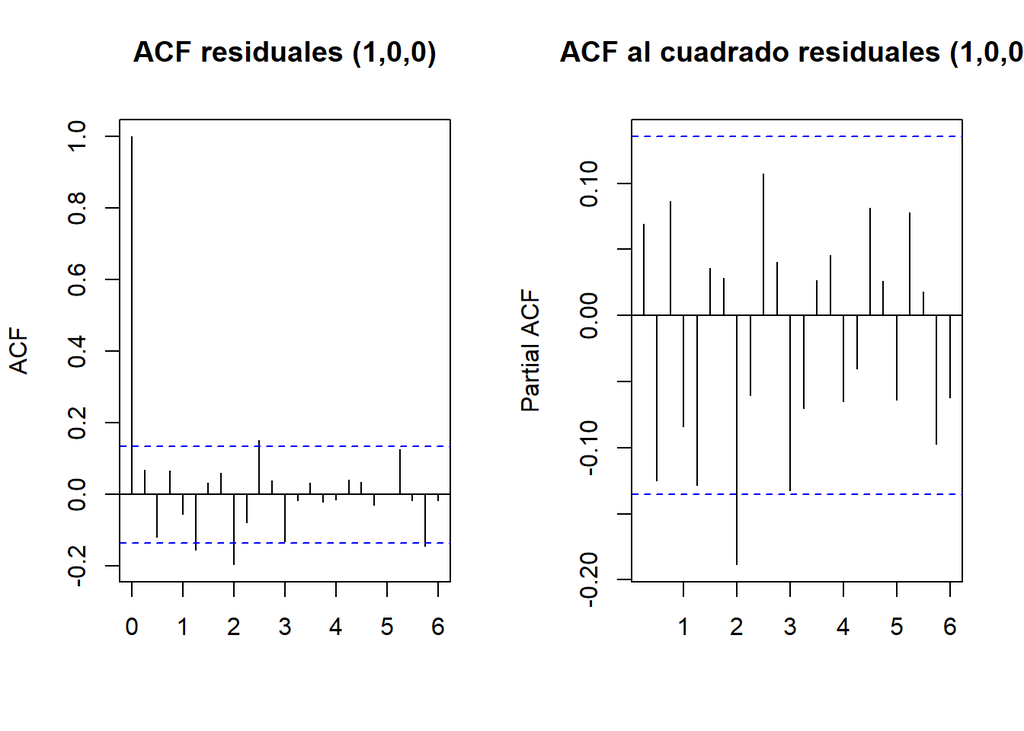

```r
res_arima_1.0.0_dlindprod = residuals(arima_1.0.0_dlindprod)

par(mfrow=c(1,2))

acf(res_arima_1.0.0_dlindprod,lag.max=24,plot=T,lwd=1,xlab='',
    main='ACF residuales (1,0,0)')
pacf(res_arima_1.0.0_dlindprod,lag.max=24,plot=T,lwd=1,xlab='',
     main='ACF al cuadrado residuales (1,0,0)')
```

Podemos ver pequeñas partes donde hay una correlación significativa, lo que indica la violación del supuesto, veamos las pruebas formales.

Generalmente las pruebas se hacen sobre un 1/4 de la muestra, pero también la haremos para otros rezagos.

```r
lags.test = length(dl.indprod)/4;lags.test
```

```
## [1] 52.5
```

Box-Pierce Test:

```r
Box.test(res_arima_1.0.0_dlindprod, lag=lags.test, type = c("Box-Pierce")) #Rechazo H0, no se cumple el supuesto.
```

```
##
##  Box-Pierce test
##
## data:  res_arima_1.0.0_dlindprod
## X-squared = 75.947, df = 52.5, p-value = 0.01882
```

```r
Box.test(res_arima_1.0.0_dlindprod, lag=20, type='Box-Pierce') #Rechazo H0, no se cumple el supuesto.
```

```
##
##  Box-Pierce test
##
## data:  res_arima_1.0.0_dlindprod
## X-squared = 30.93, df = 20, p-value = 0.05613
```

Veamos que con 20 rezagos no se rechaza la hipótesis nula, como analistas, vamos a descartar el modelo ya que viola el supuesto de no autocorrelación serial con un 1/4 de la muestra.

Pd: Recuerden que si estamos interesados en hacer un pronóstico a corto plazo, los rezagos más cercanos son los que cobran mayor relevancia. Por lo qué, si en sus trabajos el supuesto no se viola a pocos rezagos (Mínimo 20) pueden justificar esta cantidad y no una tan grande como un 1/4 de la muestra con el argumento de que plantean un pronóstico a corto plazo.

Ljung-Box:

```r
Box.test(res_arima_1.0.0_dlindprod, lag=lags.test, type = c("Ljung-Box")) #Rechazo H0, no se cumple el supuesto.
```

```
##
##  Box-Ljung test
##
## data:  res_arima_1.0.0_dlindprod
## X-squared = 86.754, df = 52.5, p-value = 0.002051
```

```r
Box.test(res_arima_1.0.0_dlindprod , lag=20, type='Ljung-Box') #Rechazo H0, no se cumple el supuesto.
```

```
##
##  Box-Ljung test
##
## data:  res_arima_1.0.0_dlindprod
## X-squared = 32.41, df = 20, p-value = 0.03912
```

Como se rechaza la H0 para los dos test anteriores significa que el modelo ARIMA(1,0,0) escogido para modelar la serie dl.indprod no alcanza a capturar toda la estructura de correlación en la serie y eso se refleja en la presencia de correlación en los residuales. Este supuesto particularmente es el más importante para pronosticar, como nuestro modelo (1,0,0) no lo cumple, *descartamos* el ARIMA(1,0,0).

La solución seria agregar más residuos autoregresivos o algunas componente de media móvil.

**ARIMA(2,0,4)**

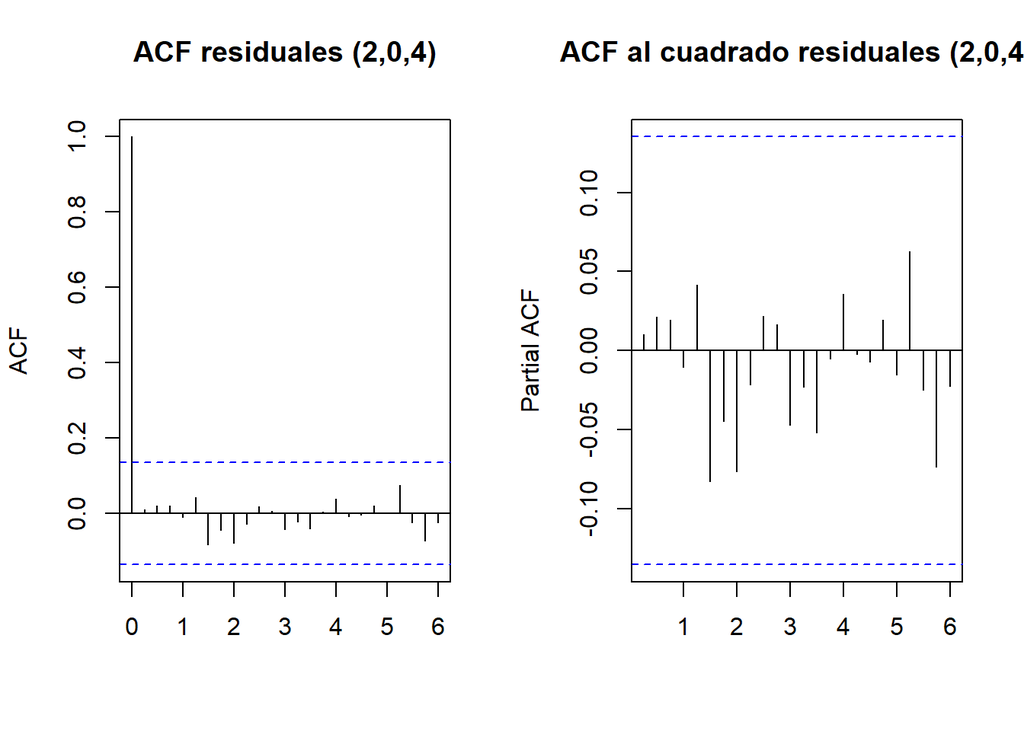

```r
res_arima_2.0.4_dlindprod = residuals(arima_2.0.4_dlindprod)

par(mfrow=c(1,2))

acf(res_arima_2.0.4_dlindprod,lag.max=24,plot=T,lwd=1,xlab='',
    main='ACF residuales (2,0,4)')
pacf(res_arima_2.0.4_dlindprod,lag.max=24,plot=T,lwd=1,xlab='',
     main='ACF al cuadrado residuales (2,0,4)')
```

Podemos ver que no existeuna correlación significativa, lo que indica el cumplimiento del supuesto, veamos las pruebas formales.

Box-Pierce Test:

```r
Box.test(res_arima_2.0.4_dlindprod, lag=lags.test, type = c("Box-Pierce")) # No rechazo H0, se cumple el supuesto.
```

```
##
##  Box-Pierce test
##
## data:  res_arima_2.0.4_dlindprod
## X-squared = 32.126, df = 52.5, p-value = 0.988
```

```r
Box.test(res_arima_2.0.4_dlindprod, lag=20, type='Box-Pierce') # No rechazo H0, se cumple el supuesto.
```

```
##
##  Box-Pierce test
##
## data:  res_arima_2.0.4_dlindprod
## X-squared = 5.2019, df = 20, p-value = 0.9996
```

Ljung-Box:

```r
Box.test(res_arima_2.0.4_dlindprod, lag=lags.test, type = c("Ljung-Box")) # No rechazo H0, se cumple el supuesto.
```

```
##
##  Box-Ljung test
##
## data:  res_arima_2.0.4_dlindprod
## X-squared = 38.309, df = 52.5, p-value = 0.9289
```

```r
Box.test(res_arima_2.0.4_dlindprod , lag=20, type='Ljung-Box') # No rechazo H0, se cumple el supuesto.
```

```
##
##  Box-Ljung test
##
## data:  res_arima_2.0.4_dlindprod
## X-squared = 5.4743, df = 20, p-value = 0.9994
```

Como no se rechaza la H0 para los dos test anteriores significa que el modelo ARIMA(2,0,4) cumple satisfactoriamente, por lo que conservamos este modelo para la verificación de siguientes supuestos.

**ARIMA(4,0,2)**

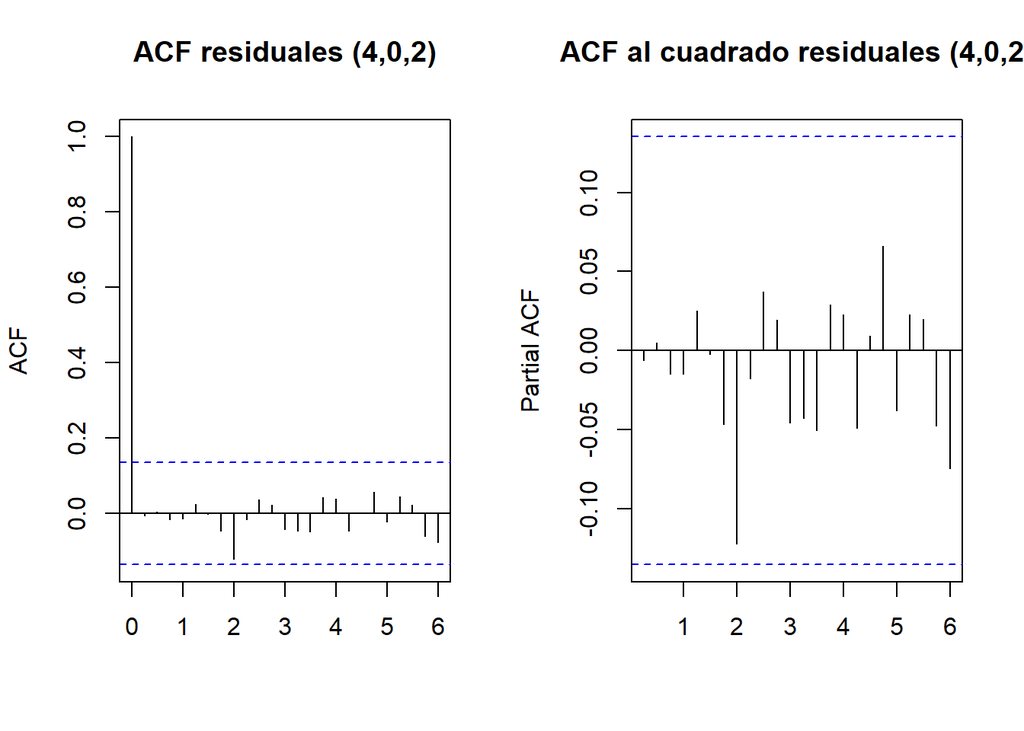

```r
res_arima_4.0.2_dlindprod = residuals(arima_4.0.2_dlindprod)

par(mfrow=c(1,2))

acf(res_arima_4.0.2_dlindprod,lag.max=24,plot=T,lwd=1,xlab='',
    main='ACF residuales (4,0,2)')
pacf(res_arima_4.0.2_dlindprod,lag.max=24,plot=T,lwd=1,xlab='',
     main='ACF al cuadrado residuales (4,0,2)')
```

Al igual que el ARIMA(2,0,4) estas gráficas no muestran autocorrelación significativa por lo que da indicios a cumplir el supuesto. Veamos las pruebas formales.

Box-Pierce Test:

```r
Box.test(res_arima_4.0.2_dlindprod, lag=lags.test, type = c("Box-Pierce")) # No rechazo H0, se cumple el supuesto.
```

```
##
##  Box-Pierce test
##
## data:  res_arima_4.0.2_dlindprod
## X-squared = 33.221, df = 52.5, p-value = 0.9826
```

```r
Box.test(res_arima_4.0.2_dlindprod, lag=20, type='Box-Pierce') # No rechazo H0, se cumple el supuesto.
```

```
##
##  Box-Pierce test
##
## data:  res_arima_4.0.2_dlindprod
## X-squared = 7.5236, df = 20, p-value = 0.9946
```

Ljung-Box:

```r
Box.test(res_arima_4.0.2_dlindprod, lag=lags.test, type = c("Ljung-Box")) # No rechazo H0, se cumple el supuesto.
```

```
##
##  Box-Ljung test
##
## data:  res_arima_4.0.2_dlindprod
## X-squared = 39.278, df = 52.5, p-value = 0.9117
```

```r
Box.test(res_arima_4.0.2_dlindprod , lag=20, type='Ljung-Box') # No rechazo H0, se cumple el supuesto.
```

```
##
##  Box-Ljung test
##
## data:  res_arima_4.0.2_dlindprod
## X-squared = 8.0293, df = 20, p-value = 0.9917
```

Como no se rechaza la H0 para los dos test anteriores significa que el modelo ARIMA(4,0,2) cumple satisfactoriamente, por lo que conservamos este modelo para la verificación de siguientes supuestos. Tenemos dos finalistas.

## 3.2. Homocedasticidad de los residuales

Ahora vamos a mirar el supuesto de homocedasticidad con un test de efectos ARCH. La prueba nos dice que si los residuales son heterocedasticos, los residuales al cuadrado deben estar correlacionados. Hay dos formas de hacer la prueba: Un test Pormenteau y un Test tipo multiplicadores de Lagrange. Podremos ver si existe heterocedasticidad con las FAC y FACP.

Nuevamente, veremos un argumento gráfico y uno formal.

**ARIMA(2,0,4)**

Prueba arch (Pormnteau y Mult. de Lagrange): En esta prueba buscamos rechazar la hipótesis nula a favor de heterocedasticidad en los residuales.

```r
arch_dlindprod_arima_2.0.4 = arch.test(arima_2.0.4_dlindprod, output=TRUE)
```

```
## ARCH heteroscedasticity test for residuals
## alternative: heteroscedastic
##
## Portmanteau-Q test:
##      order   PQ  p.value
## [1,]     4 19.6 0.000595
## [2,]     8 28.9 0.000325
## [3,]    12 33.2 0.000893
## [4,]    16 40.4 0.000677
## [5,]    20 40.9 0.003871
## [6,]    24 54.9 0.000320
## Lagrange-Multiplier test:
##      order     LM  p.value
## [1,]     4 102.59 0.00e+00
## [2,]     8  44.29 1.88e-07
## [3,]    12  20.90 3.44e-02
## [4,]    16  14.10 5.18e-01
## [5,]    20   9.69 9.60e-01
## [6,]    24   6.72 1.00e+00
```

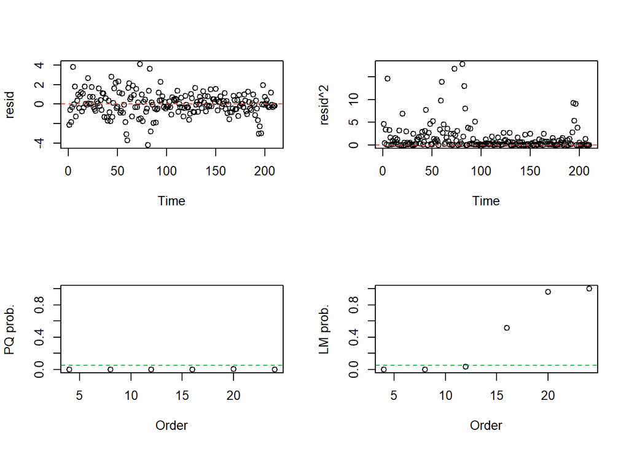

Como ya se mencionó, la correlación serial de los residuales al cuadrado del modelo ARIMA es una proxy de heterocedasticidad, por lo que una FAC y FACP de los residuales al cuadrado es una buena forma de establecer si hay heterocedasticidad o no en dichos residuales. Dado que el comando anterior a veces no da tanta claridad sobre la severidad de la heterocedasticidad en la serie, siempre se recomienda realizar la ACF y PACF de los residuales del modelo ARIMA al cuadrado para verificar la presencia y la severidad de la heterocedasticidad.

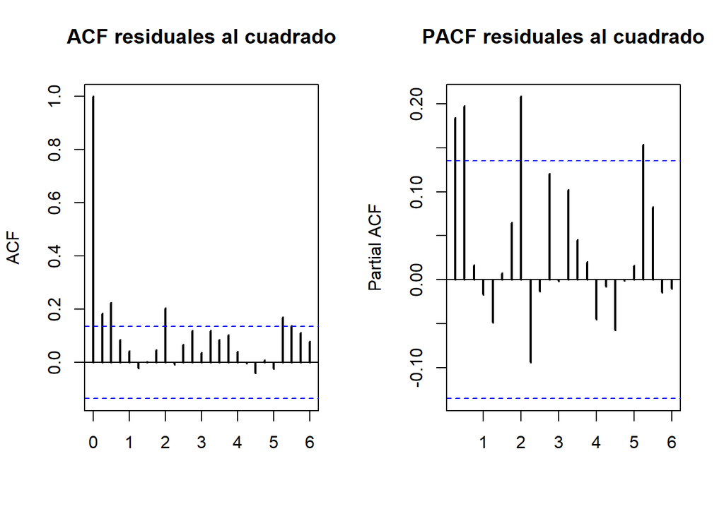

```r
par(mfrow=c(1,2))
acf(res_arima_2.0.4_dlindprod^2,lag.max=lags,plot=T,lwd=2,xlab='',main='ACF residuales al cuadrado')
pacf(res_arima_2.0.4_dlindprod^2,lag.max=lags,plot=T,lwd=2,xlab='',main='PACF residuales al cuadrado')
```

Las FAC y FACP parecen indicar heterocedasticidad. Como este supuesto no es tan relevante como el de no autocorrelación, conservaremos momentaneamente nuestro modelo.

Nota: Las gráficas de la FAC y FACP de los residuales al cuadrado parecen corroborar que la serie presenta heterocedasticidad. Se recomienda utilizar modelos menos parsimoniosos como el que propone el AIC. En caso, de que persista la heterocedasticidad, una forma de tratarla es empleando modelos garch.

**ARIMA(4,0,2)**

Prueba arch:

```r
arch_dlindprod_arima_4.0.2 = arch.test(arima_4.0.2_dlindprod, output=TRUE)
```

```
## ARCH heteroscedasticity test for residuals
## alternative: heteroscedastic
##
## Portmanteau-Q test:
##      order   PQ  p.value
## [1,]     4 16.1 0.002830
## [2,]     8 23.4 0.002928
## [3,]    12 27.0 0.007769
## [4,]    16 40.3 0.000711
## [5,]    20 41.3 0.003409
## [6,]    24 51.3 0.000965
## Lagrange-Multiplier test:
##      order     LM  p.value
## [1,]     4 119.84 0.00e+00
## [2,]     8  52.11 5.55e-09
## [3,]    12  26.28 5.89e-03
## [4,]    16  15.40 4.23e-01
## [5,]    20  10.19 9.48e-01
## [6,]    24   7.31 9.99e-01
```

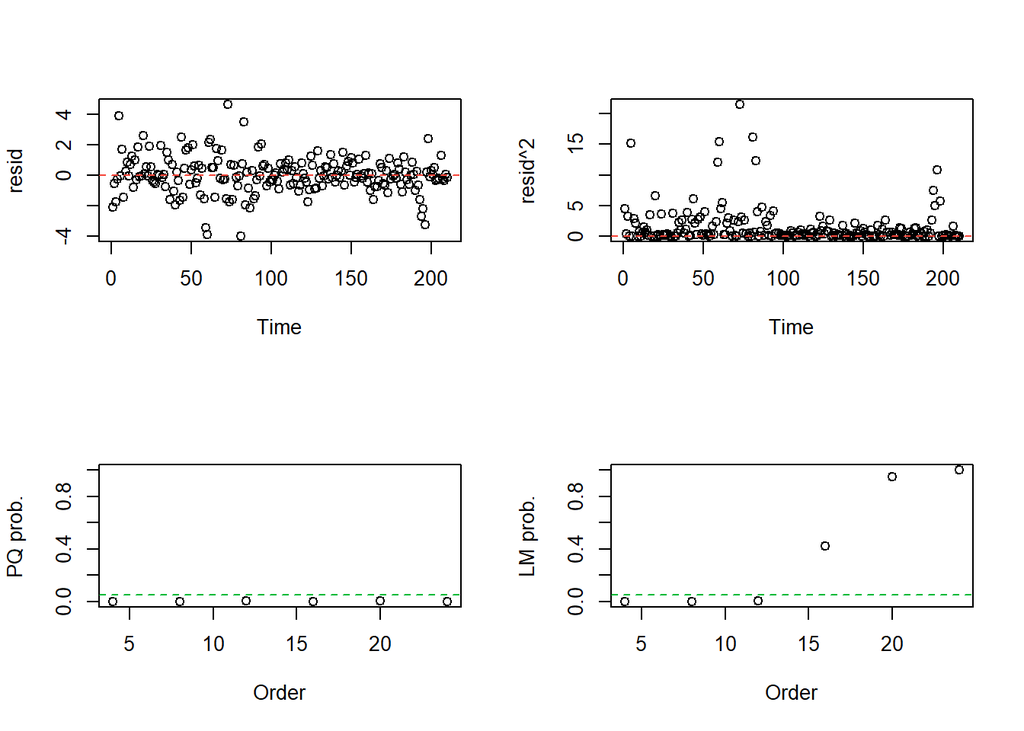

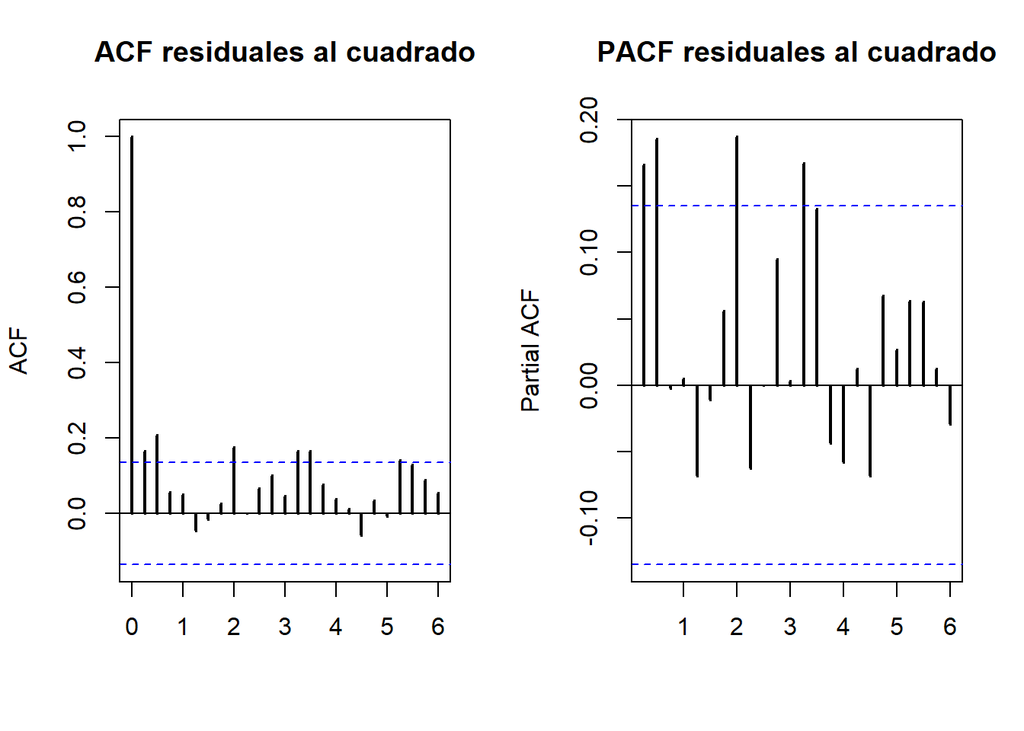

```r
par(mfrow=c(1,2))
acf(res_arima_4.0.2_dlindprod^2,lag.max=lags,plot=T,lwd=2,xlab='',main='ACF residuales al cuadrado')
pacf(res_arima_4.0.2_dlindprod^2,lag.max=lags,plot=T,lwd=2,xlab='',main='PACF residuales al cuadrado')
```

Esto indica heterocedasticidad, no se cumple el supuesto.

## 3.3. Normalidad en los errores

Veremos si los residuales se comportan de manera normal (distribución normal) para ello usaremos un argumento gráfico como el QQ-plot y la prueba de normalidad Jarque-Bera. El test Jarque Bera tiene como hipótesis nula la normalidad de los errores.

**ARIMA(2,0,4)**

QQ-plot

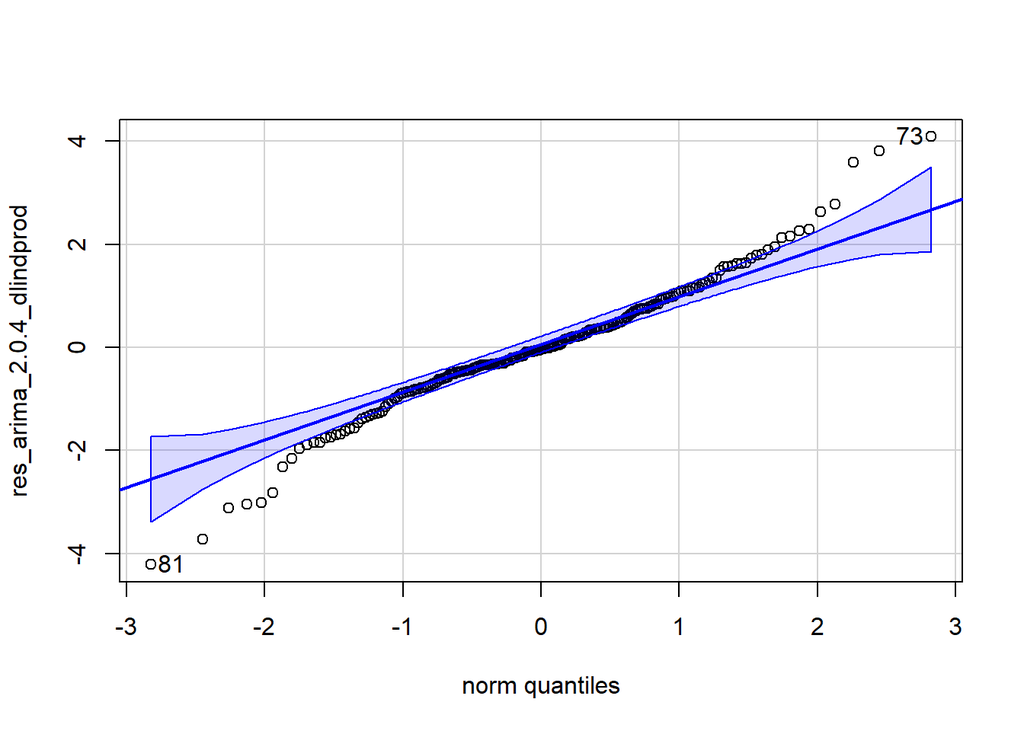

```
## [1] 81 73
```

```r
qqPlot(res_arima_2.0.4_dlindprod)
```

Notemos que este gráfico nos muestra que los errores tienen colas pesadas (los puntos que se encuentran afuera de la onda azul en los extremos) lo que sugiere la no-normalidad en los residuos.

Test Jarque-Bera

```r
jarque.bera.test(res_arima_2.0.4_dlindprod)
```

```
##
##  Jarque Bera Test
##
## data:  res_arima_2.0.4_dlindprod
## X-squared = 27.569, df = 2, p-value = 1.031e-06
```

Rechazamos H0, lo que implica la violación del supuesto.

**ARIMA(4,0,2)**

QQ-plot

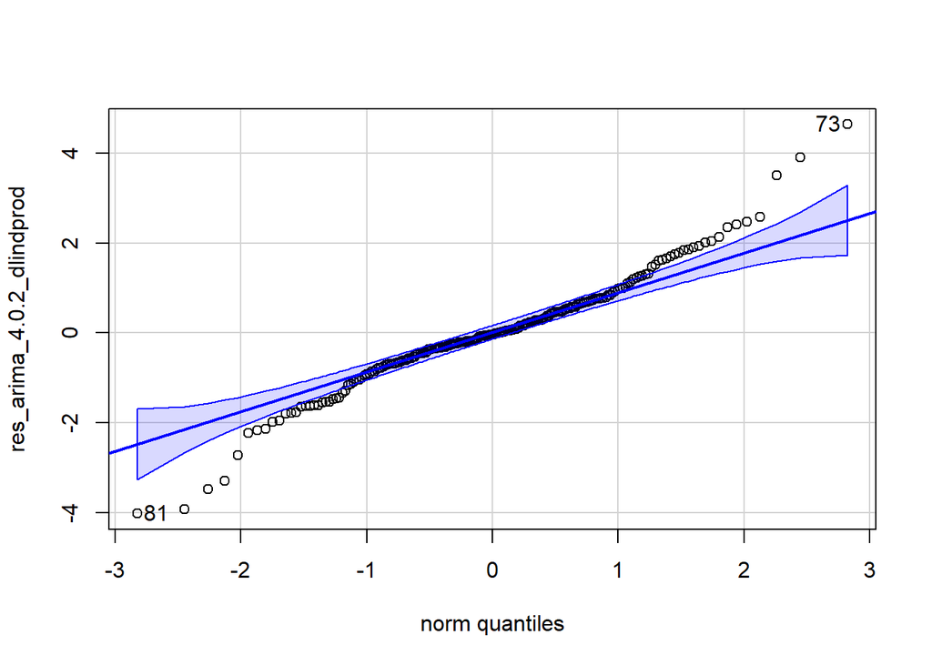

```
## [1] 73 81
```

```r
qqPlot(res_arima_4.0.2_dlindprod)
```

Nuevamente se nos muestra que los errores tienen colas pesadas, lo que sugiere la no-normalidad en los residuos.

Test Jarque-Bera

```r
jarque.bera.test(res_arima_4.0.2_dlindprod)
```

```
##
##  Jarque Bera Test
##
## data:  res_arima_4.0.2_dlindprod
## X-squared = 40.405, df = 2, p-value = 1.683e-09
```

Rechazamos H0, lo que implica la violación del supuesto.

Es muy usual en la práctica, que al modelar series de tiempo los residuales de la serie no satisfagan el supuesto de normalidad. Esto puede generar dificultad, en la medida de que la inferencia estadística convencional no es correcta a pesar de que los pronósticos puntuales sí son correctas (sin importar si los residuales se comportan normal o no). No obstante, como nos interesa realizar pronósticos con intervalos de confianza es necesario emplear una distribución que se acomode lo mejor posible a los residuales del modelo. Esto se puede lograr empleando bootstrapping, que es una forma de simular la distribución de una muestra de datos realizando un remuestreo con reemplazo de éstos. La función forecast del paquete forecast no permite hacer bootsrapping mientras que la función forecast del paquete fable sí lo permite.

Conclusiones:

- Se descarta el ARIMA(1,0,0) al violar el supuesto de mayor importancia.
- ARIMA(2,0,4) y ARIMA(4,0,2) no cumplen los supuestos de homocedasticidad y normalidad pero esto no es tan perjudicial como violar el supuesto de no autocorrelacción serial, por lo que seguimos trabajando con estos modelos.

**EXTRA:** Como un extra podremos verificar estacionariedad con un gráfico del paquete fable sobre las raices fuera del circulo unitario.

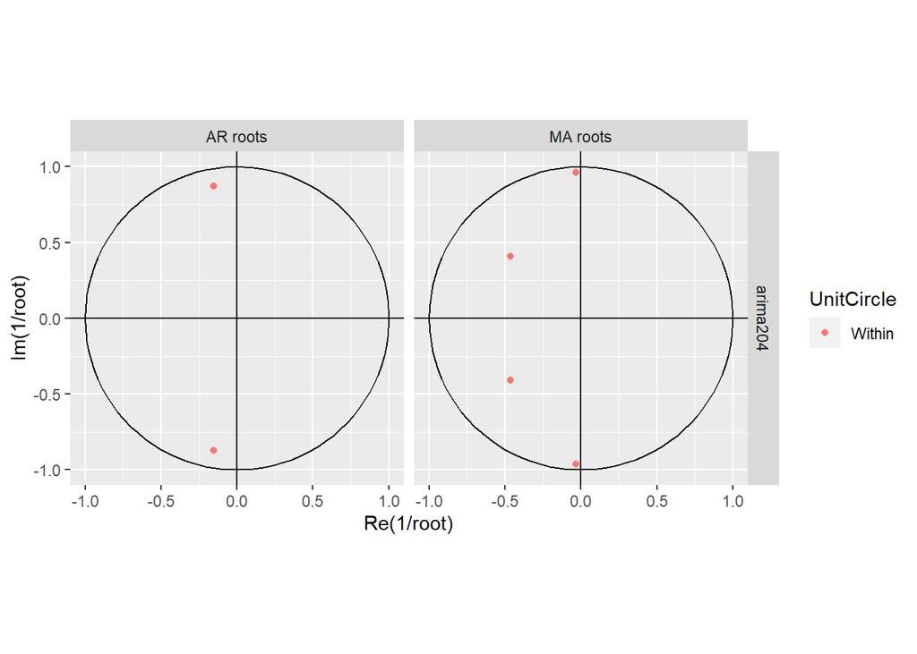

```r
gg_arma(arima_2.0.4_dlindprod_fable)
```

# 4. Cuarto paso: Pronóstico

Dado que el modelo arima(1,0,0) no cumple el supuesto más importante de no correlación serial de los errores, en oposición con los modelos arima(2,0,4) y arima(4,0,2), solamente vamos a hacer los pronósticos con base en el arima(2,0,4), (recuerden que la razón principal para utilizar un modelo ARIMA es para generar pronósticos de corto plazo).

Tengan en cuenta que si bien el presente Script es bastante extenso (porque busca mostrarles todas las herramientas y todo lo que tienen que tener en cuenta a la hora de estimar un modelo ARIMA en R), a la hora de presentar **sus talleres solo tienen que escoger un modelo que sea adecuado modelar por la metodología Box Jenkins** y con el cual puedan hacer pronósticos y en lo posible que satisfaga al menos el supuesto de no correlación serial de los residuales.

## 4.1. Pronósticos futuros

Los intervalos de confianza que aparecen en los pronósticos que no emplean bootstrapping no son buenos dado que no se cumple el supuesto de normalidad en los residuales. Por tanto, para hacer buenos pronósticos con intervalos de confianza correctos es necesario emplear bootstrapping Esto es posible empleando la función forecast del paquete fable, que permite hacer pronósticos con bootrapping. Es importante resaltar que para usar dicho comando se necesita proveer un objeto estimado por el comando ARIMA del paquete fable.

Otro factor a considerar es que si empleamos un pronóstico ahora, obtendremos el pronostico de la serie diferenciada. Una manera de obtener los pronóstico en los datos con el logaritmo de nivel, creamos una estimación donde el comando haga la diferencia por su cuenta. Tranquilos, no cambia nada, es exactamente el mismo proceso pero incluyendo la diferenciación de la serie en la estimación.

```r
# ARIMA(2,1,4) sobre la variable base en logaritmo

arima_2.1.4_lindprod_fable  = as_tsibble(l.indprod) %>%
  model(arima214 = ARIMA(value ~ pdq(2,1,4) + PDQ(0, 0, 0)))

arima_2.1.4_lindprod = arima(l.indprod, order = c(2,1,4),
                              include.mean = T, method = "ML")
```

A la hora de hacer simulaciones, ya sea de Monte Carlo o bootrapping se recomienda realizar al menos 10.000 simulaciones Esto va a demorar un tiempo (al menos entre 1 a 2 minutos). Los tiempos difieren dependiendo del proesador y memoría RAM del PC que estén empleando.

Si bien la simulación por bootstrapping es la metodología más empleada a la hora de trabajar con series que no tienen un comportamiento normal se resalta que un bootstrapping convencional no es valido en caso de que la serie además de presentar no normalidad presente heterocedasticidad,como es el caso de nuestra serie. En este caso, se recomienda emplear modelos de volatilidad condicional (AKA como GARCH) en donde se estimen dichos modelos asumiendo que los errores siguen una distribución diferente a la normal (como una t con pocos grados de libertad, que suele tener colas más pesadas que una normal, i.e. es una distribución leptocúrtica). Lo anterior, se puede realizar en R empleando el paquete “rugarch” que es un paquete muy versatil no solo para estimar modelos GARCH sino también estimarlos con distribuciones que permiten modelar errores no necesariamente normales.

No obstante, para efectos prácticos del curso de econometría II, como los modelos GARCH están por fuera de la temática del curso, pueden emplear la función forecast de fable para tratar problemas de no normalidad independiente de que haya heterocesdasticidad o no en los errores.

**Pronóstico ARIMA(2,0,4)**

Veamos el pronóstico puntual con la función forecast().

```r
forecast_arima_2.1.4_lindprod = arima_2.1.4_lindprod_fable %>%
forecast(h = 10, bootstrap = TRUE, times = 10000)

forecast_arima_2.1.4_lindprod
```

```
## # A fable: 10 x 4 [1Q]
## # Key:     .model [1]
##    .model     index         value .mean
##    <chr>      <qtr>        <dist> <dbl>
##  1 arima214 2012 Q4 sample[10000]  4.61
##  2 arima214 2013 Q1 sample[10000]  4.62
##  3 arima214 2013 Q2 sample[10000]  4.62
##  4 arima214 2013 Q3 sample[10000]  4.63
##  5 arima214 2013 Q4 sample[10000]  4.63
##  6 arima214 2014 Q1 sample[10000]  4.64
##  7 arima214 2014 Q2 sample[10000]  4.65
##  8 arima214 2014 Q3 sample[10000]  4.65
##  9 arima214 2014 Q4 sample[10000]  4.66
## 10 arima214 2015 Q1 sample[10000]  4.67
```

```r
# Predicciones a NIVEL, aplicamos euler a la predicción en logaritmo.

exp(forecast_arima_2.1.4_lindprod$.mean)
```

```
##  [1] 100.2078 101.0407 101.8386 102.2888 102.9496 103.8289 104.4481 104.9684
##  [9] 105.7288 106.5188
```

Adicionalmente, utilizando el comando hilo() que se encuentra en el paquete fable es posible mostrar tanto el valor de los pronósticos puntuales como los intervalos de predicción a diferentes niveles. level = c(80, 90, 95). Para encontrar los intervalos de predicción al 80%, 95% y 95%.

```r
pronosticos_2.1.4_lindprod = forecast_arima_2.1.4_lindprod %>%
  hilo(level = c(95))

View(pronosticos_2.1.4_lindprod)
```

Para ver el pronóstico a nivel, aplicamos euler a la media de predicción para revertir el efecto del logaritmo.

```r
exp(pronosticos_2.1.4_lindprod$.mean)
```

```
##  [1] 100.2078 101.0407 101.8386 102.2888 102.9496 103.8289 104.4481 104.9684
##  [9] 105.7288 106.5188
```

```r
exp(pronosticos_2.1.4_lindprod$`95%`)
```

```
## <hilo[10]>
##  [1] [97.23118, 102.8763]95 [95.95978, 106.1974]95 [94.85315, 109.4095]95
##  [4] [93.52886, 111.7847]95 [92.68349, 114.3376]95 [92.60544, 116.4132]95
##  [7] [92.27706, 118.3862]95 [91.79702, 120.3552]95 [91.48295, 122.4734]95
## [10] [91.36866, 124.1729]95
```

**Gráficos del pronóstico**

Con Forecast podemos ver rapidamente la variación del IPI.

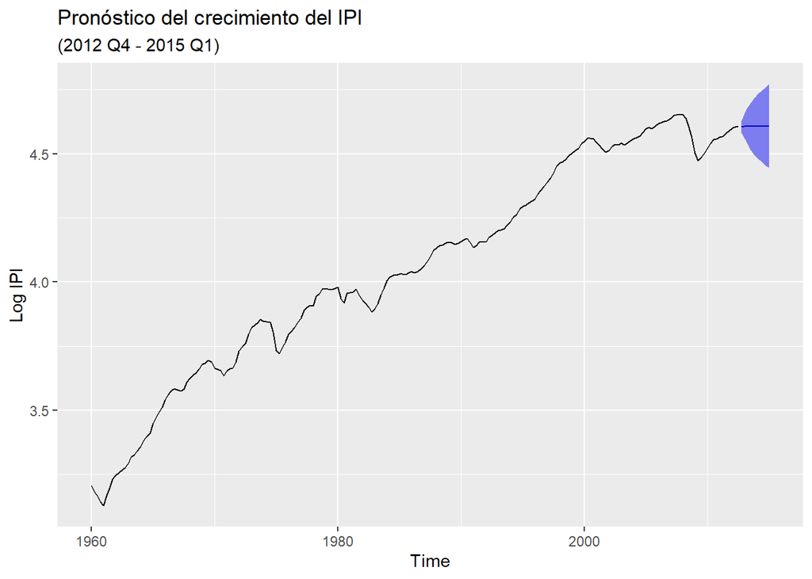

```r
pronostico = forecast(arima_2.1.4_lindprod, level = c(95), h = 10)

autoplot(pronostico, color = 'firebrick1',
         predict.linetype = 'dashed', conf.int = FALSE, ylab = "Log IPI")+
  ggtitle("Pronóstico del crecimiento del IPI", subtitle = "(2012 Q4 - 2015 Q1)")
```

Con los paquetes básicos de R, podemos hacer un gráfico manual con un pronóstico en nivel, generando manualmente intervalos de confianza.

```r
pronostico_nivel = predict(arima_2.1.4_lindprod, n.ahead = 10)
pronostico_nivel
```

```
## $pred
##          Qtr1     Qtr2     Qtr3     Qtr4
## 2012                            4.604291
## 2013 4.607483 4.609062 4.606573 4.606126
## 2014 4.608159 4.607882 4.606417 4.607073
## 2015 4.607990
##
## $se
##            Qtr1       Qtr2       Qtr3       Qtr4
## 2012                                  0.01228657
## 2013 0.02455513 0.03600659 0.04643817 0.05491845
## 2014 0.06121456 0.06720613 0.07330037 0.07856193
## 2015 0.08320576
```

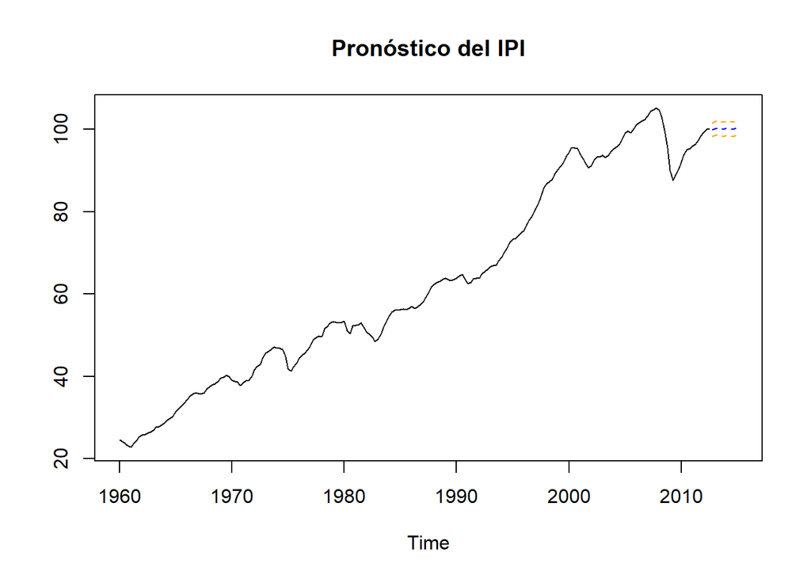

```r
# Pronosticar 10 trimestres futuros

prediccion_nivel_10Q = exp(pronostico_nivel$pred)


intervalo_sup = prediccion_nivel_10Q + qnorm(0.95, 0, 1) * exp(pronostico_nivel$se)
intervalo_inf = prediccion_nivel_10Q - qnorm(0.95, 0, 1) * exp(pronostico_nivel$se)

ts.plot(indprod, prediccion_nivel_10Q, intervalo_sup, intervalo_inf,
        col=c('black', 'blue', "orange", "orange"),lty = c(1,2,2,2),
        main = "Pronóstico del IPI")
```

## 4.2. Ajuste vs Real

Ahora, con el objetivo de analizar el rendimiento de nuestra estimación ARIMA, generamos un contrafactual de la serie original contra la que ajusta la estimación para las predicciones.

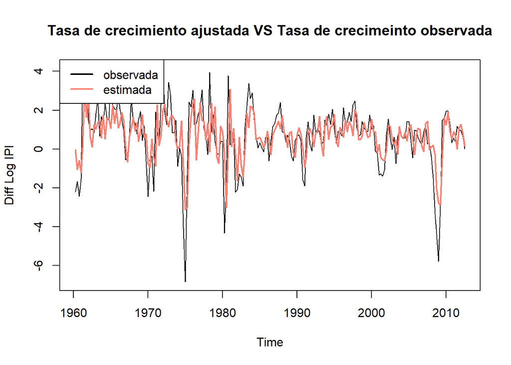

```r
fit_0 = dl.indprod - residuals(arima_2.0.4_dlindprod)


plot.ts(dl.indprod,type="l",
        main="Tasa de crecimiento ajustada VS Tasa de crecimeinto observada",
        lwd=1, ylab = "Diff Log IPI")
points(fit_0,col="salmon",lwd=2, type = "l")
legend("topleft",c("observada", "estimada"), col=c("black","salmon"),lty=1,lwd=2)
```

Como pueden observar el ajuste en muestra es bastante bueno, lo que muestra la capacidad y potencia de los modelos ARIMA.

Como pudieron notar los modelos ARMA son modelos que están diseñados para modelar series estacinoarias en covarianza. Eso implica que uno debería utilizar un modelo ARMA cuando las series se comportan con media constante, varianza constante y autocorrelación que depende solo de la distancia temporal entre las observaciones.

Para corroborar que una serie es estacionario se podría verificar que los residuales del modelo en efecto se comporten como Ruido blanco.

**Notas sobre volatilidad**

La tasa de crecimeiento del IPI pareciera presentar clusters de volatilidad, es decir, no hay una varianza constante a lo largo de la serie sino que pareciera que en determinados periodos de tiempo hay un tipo de volatilidad y en otro periodo de tiempo dicha volatilidad cambia.

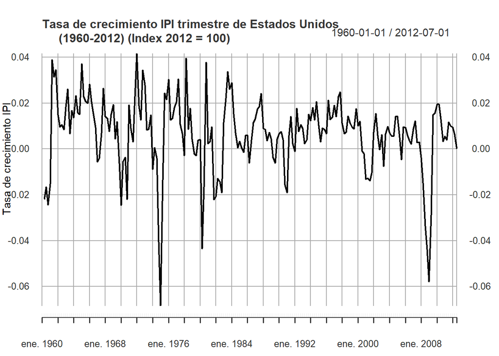

```r
plot(diff(log(indprod_xts)),
     main = "Tasa de crecimiento IPI trimestre de Estados Unidos
     (1960-2012) (Index 2012 = 100)", ylab  = "Tasa de crecimiento IPI")
```

El anterior comportamiento es muy común en muchas series de tiempo, en particular, dicho comportamiento de presencia de varios clusters diferentes de volatilidad en una misma serie tiende a ser común en series de tiempo financieras.

Dado que los modelos ARMA están diseñados para series con varianza constante se requiere de otro tipo de modelos capaces de capturar esos esos clusters de volatilidad. Para ello, se emplean modelos capaces de modelar la varianza variable en el tiempo del proceso generador de datos

Dichos modelos son:

- ARCH: Extensión del modelo AR para modelar series de tiempo con clusters de volatilidad
- GARCH: Extensión del modelo ARMA para modelar serie de tiempo con clusters de volatilidad (en la práctica se emplean más porque genera modelos más parsimoniosos)

En R el paquete más comúnmente empleado para modelos GARCH univariados es “rugarch” y para modelos GARCH multivariados es “rmgarch”.